# IODS course project

# Logistic regression

Load libraries

```r
library(tidyr)
library(dplyr)
```

```r
library(ggplot2)
```

1. Read the data from local folder and check for structure and dimensions. Print out the names of the variables in the data and describe the data set briefly, assuming the reader has no previous knowledge of it.

```r
alc <- read.table("C:/LocalData/kpuukko/IODS-project/data/alc.txt", sep="\t")

#There are 382 observations and 35 variables in the data set
str(alc)
```

```
## 'data.frame':    382 obs. of  35 variables:
##  $ school    : chr  "GP" "GP" "GP" "GP" ...
##  $ sex       : chr  "F" "F" "F" "F" ...
##  $ age       : int  18 17 15 15 16 16 16 17 15 15 ...
##  $ address   : chr  "U" "U" "U" "U" ...
##  $ famsize   : chr  "GT3" "GT3" "LE3" "GT3" ...
##  $ Pstatus   : chr  "A" "T" "T" "T" ...
##  $ Medu      : int  4 1 1 4 3 4 2 4 3 3 ...
##  $ Fedu      : int  4 1 1 2 3 3 2 4 2 4 ...
##  $ Mjob      : chr  "at_home" "at_home" "at_home" "health" ...
##  $ Fjob      : chr  "teacher" "other" "other" "services" ...
##  $ reason    : chr  "course" "course" "other" "home" ...
##  $ nursery   : chr  "yes" "no" "yes" "yes" ...
##  $ internet  : chr  "no" "yes" "yes" "yes" ...
##  $ guardian  : chr  "mother" "father" "mother" "mother" ...
```

[output cut: 21 more lines]

```r
dim(alc)
```

```
## [1] 382  35
```

```r
summary(alc)
```

```
##     school              sex                 age          address
##  Length:382         Length:382         Min.   :15.00   Length:382
##  Class :character   Class :character   1st Qu.:16.00   Class :character
##  Mode  :character   Mode  :character   Median :17.00   Mode  :character
##                                        Mean   :16.59
##                                        3rd Qu.:17.00
##                                        Max.   :22.00
##    famsize            Pstatus               Medu            Fedu
##  Length:382         Length:382         Min.   :0.000   Min.   :0.000
##  Class :character   Class :character   1st Qu.:2.000   1st Qu.:2.000
##  Mode  :character   Mode  :character   Median :3.000   Median :3.000
##                                        Mean   :2.806   Mean   :2.565
##                                        3rd Qu.:4.000   3rd Qu.:4.000
##                                        Max.   :4.000   Max.   :4.000
##      Mjob               Fjob              reason            nursery
##  Length:382         Length:382         Length:382         Length:382
##  Class :character   Class :character   Class :character   Class :character
##  Mode  :character   Mode  :character   Mode  :character   Mode  :character
##
##
##
##    internet           guardian           traveltime      studytime
##  Length:382         Length:382         Min.   :1.000   Min.   :1.000
##  Class :character   Class :character   1st Qu.:1.000   1st Qu.:1.000
##  Mode  :character   Mode  :character   Median :1.000   Median :2.000
##                                        Mean   :1.448   Mean   :2.037
##                                        3rd Qu.:2.000   3rd Qu.:2.000
##                                        Max.   :4.000   Max.   :4.000
##     failures       schoolsup            famsup              paid
##  Min.   :0.0000   Length:382         Length:382         Length:382
##  1st Qu.:0.0000   Class :character   Class :character   Class :character
##  Median :0.0000   Mode  :character   Mode  :character   Mode  :character
##  Mean   :0.2016
##  3rd Qu.:0.0000
##  Max.   :3.0000
##   activities           higher            romantic             famrel
##  Length:382         Length:382         Length:382         Min.   :1.000
##  Class :character   Class :character   Class :character   1st Qu.:4.000
##  Mode  :character   Mode  :character   Mode  :character   Median :4.000
##                                                           Mean   :3.937
```

[output cut: 8 more lines]

```
##  Max.   :5.00   Max.   :5.000   Max.   :5.000   Max.   :5.000   Max.   :5.000
##     absences          G1              G2              G3           alc_use
##  Min.   : 0.0   Min.   : 2.00   Min.   : 4.00   Min.   : 0.00   Min.   :1.000
##  1st Qu.: 1.0   1st Qu.:10.00   1st Qu.:10.00   1st Qu.:10.00   1st Qu.:1.000
##  Median : 3.0   Median :12.00   Median :12.00   Median :12.00   Median :1.500
##  Mean   : 4.5   Mean   :11.49   Mean   :11.47   Mean   :11.46   Mean   :1.889
##  3rd Qu.: 6.0   3rd Qu.:14.00   3rd Qu.:14.00   3rd Qu.:14.00   3rd Qu.:2.500
##  Max.   :45.0   Max.   :18.00   Max.   :18.00   Max.   :18.00   Max.   :5.000
##   high_use
##  Mode :logical
##  FALSE:268
##  TRUE :114
##
##
##
```

```r
#Names of the variables
colnames(alc)
```

```
##  [1] "school"     "sex"        "age"        "address"    "famsize"
##  [6] "Pstatus"    "Medu"       "Fedu"       "Mjob"       "Fjob"
## [11] "reason"     "nursery"    "internet"   "guardian"   "traveltime"
## [16] "studytime"  "failures"   "schoolsup"  "famsup"     "paid"
## [21] "activities" "higher"     "romantic"   "famrel"     "freetime"
## [26] "goout"      "Dalc"       "Walc"       "health"     "absences"
## [31] "G1"         "G2"         "G3"         "alc_use"    "high_use"
```

```r
table(alc$sex) #198 Female and 184 Male students
```

```
##
##   F   M
## 198 184
```

```r
table(alc$age) # Age distribution is from 15 to 22, most of the students are 16 or 17 years old.
```

```
##
##  15  16  17  18  19  20  22
##  81 107 100  81  11   1   1
```

```r
table(alc$high_use) #114 of students are high alcohol users, 268 are not
```

```
##
## FALSE  TRUE
##   268   114
```

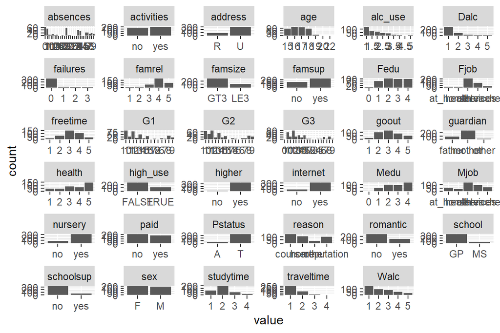

```r
# A bar plot of each variable
gather(alc) %>% ggplot(aes(value)) + facet_wrap("key", scales = "free") + geom_bar()
```

2. I will study the relationship between gender, school absenses, going out, famrel and alcohol consumption

Hypothesis

H1: High quality of family relationships reduce the risk for high alcohol consumption. H2: School absenses increase the risk for high alcohol consumption. H3: Going out increases the risk for high alcohol consumption. H4: Male students use more alcohol than female students.

3. Numerically and graphically explore the distributions of your chosen variables and their relationships with alcohol consumption (use for example cross-tabulations, bar plots and box plots). Comment on your findings and compare the results of your exploration to your previously stated hypotheses. (0-5 points)

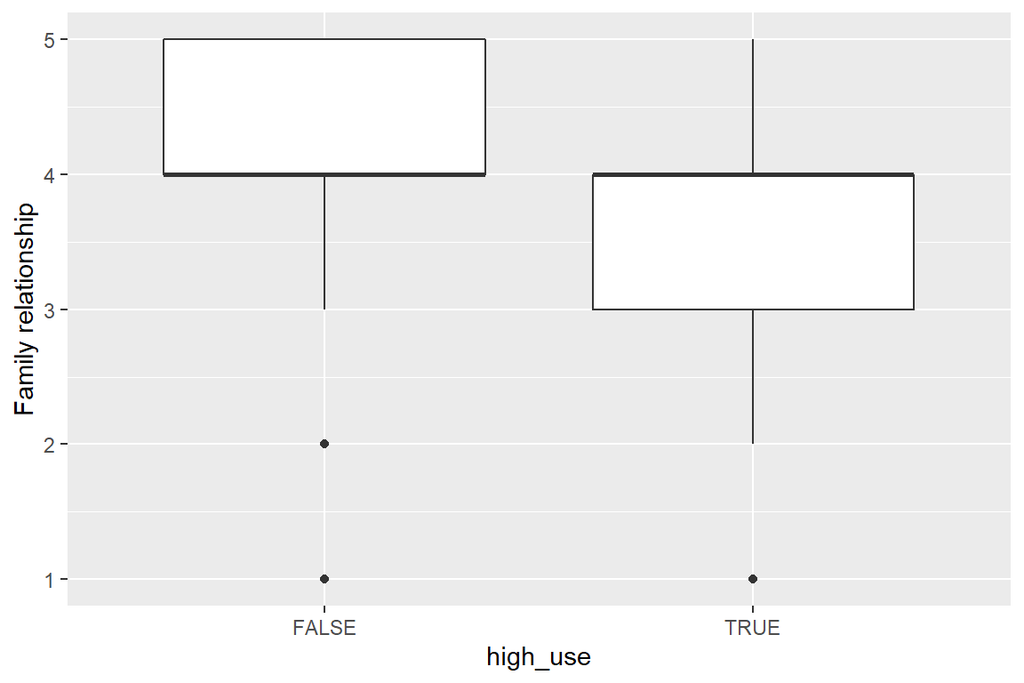

```r
# A box plot of high_use and family relationship
#As assumed, students who are high alcohol users have lower quality family relationships.
g1 <- ggplot(alc, aes(x = high_use, y = famrel))
g1 + geom_boxplot() + ylab("Family relationship")
```

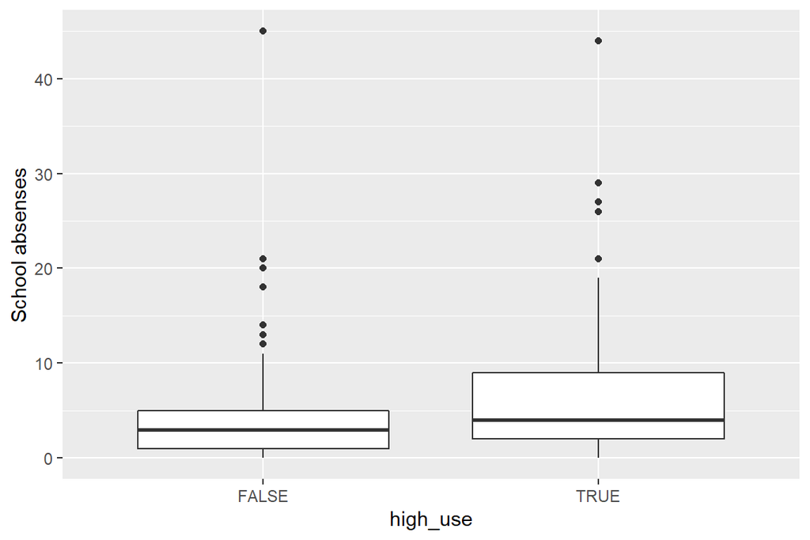

```r
# A box plot of high_use and school absenses
#Students who consume more alcohol have slightly more school absenses compared to students who are not high users. However, the differences between the groups appears really small.
g2 <- ggplot(alc, aes(x = high_use, y = absences))
g2 + geom_boxplot() + ylab("School absenses")
```

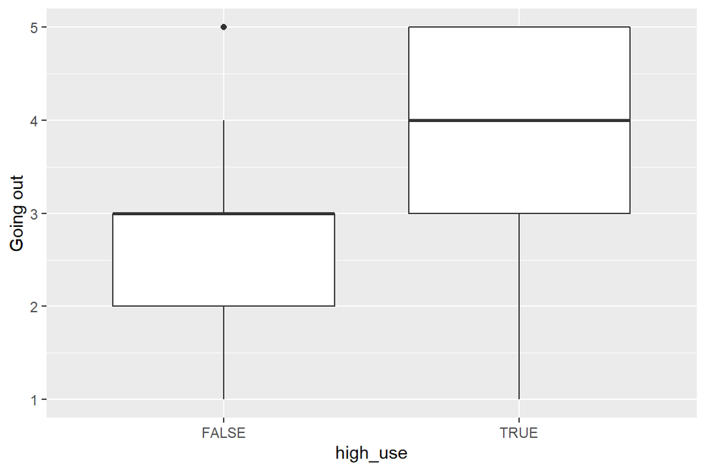

```r
# A box plot of high_use and going out
#As assumed, students who are high alcohol users go out more than other students.
g3 <- ggplot(alc, aes(x = high_use, y = goout))
g3 + geom_boxplot() + ylab("Going out")
```